# Categorical Data: Basics of Barplots

February 11, 2026 @ 05:42 PM

## Before We Begin…

These slides are not meant to be standalone information. You should take notes to flesh out the contents. I recommend that you create an R Markdown document where you can combine information and code from the slides and your own additional notes and explorations to make connections.

**Related Materials**

- Ch04 of [*Introduction to Modern Statistics, 2nd Edition*](https://openintro-ims.netlify.app/explore-categorical)
- Ch02 of [*Modern Dive, 2nd Edition*](https://moderndive.com/v2/viz.html)
- Ch03 of [*Modern Dive, 2nd Edition*](https://moderndive.com/v2/wrangling.html)
- DataCamp [*Introduction to the Tidyverse*](https://www.datacamp.com/courses/introduction-to-the-tidyverse)
- DataCamp [*Introduction to Data Visualization with ggplot2*](https://app.datacamp.com/learn/courses/introduction-to-data-visualization-with-ggplot2)
- [*R Graphics Cookbook, 2nd Edition*](https://r-resources.massey.ac.nz/rgcookbook/)

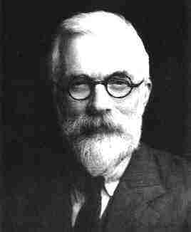

“…the object of statistical methods is the reduction of data. A quantity of data, which usually by its mere bulk is incapable of entering the mind, is to be replaced by relatively few quantities which shall adequately represent the whole, or…shall contain as much as possible, ideally the whole, of the relevant information contained in the original data.” ~ R.A. Fisher, 1921

## How We Describe Data Distributions

**Categorical Variables**

- frequency / relative frequency

Summaries based on *counting* how often categories occur.

**Numerical Variables**

- shape
- center
- spread
- outliers

*Shape*, *center*, and *spread* characterize the distribution pattern of numerical variables. *Outliers* are deviations from the pattern.

## Exploring Categorical Data

- frequency / relative frequency table
- cumulative frequency / cumulative relative frequency table
- contingency table
- [bar chart / barplot](https://ggplot2.tidyverse.org/reference/geom_bar.html)
- mosaic plot
- waffle plot
- pie chart

Statisticians rarely use pie charts, but they are popular in media. “There is no data that can be displayed in a pie chart that cannot be displayed better in some other type of chart.”

(*Quote attributed to John Tukey. It is unverified, but generally true.*)

## Berkeley Data

In the early 1970s, UC Berkeley was concerned about possible sex discrimination in grad school admissions. The berkeley.csv dataset contains fall 1973 data for the six largest departments. Click the link to get the URL for the dataset.

The Berkeley data is an example of a concept in statistics called [Simpson’s Paradox](https://en.wikipedia.org/wiki/Simpson%27s_paradox).

You can load the data into `R` using the URL and the code below.

`library(tidyverse)`

`berkdata <- read_csv("https://raw.githubusercontent.com/STAT-JET-ASU/Datasets/master/Instructor/berkeley.csv")`

## Inspect the Dataset

```r
glimpse(berkdata)
```

```
Rows: 4,526
Columns: 3
$ sex        <chr> "male", "male", "male", "male", "male", "male", "male", "ma…
$ department <chr> "A", "A", "A", "A", "A", "A", "A", "A", "A", "A", "A", "A",…
$ status     <chr> "accepted", "accepted", "accepted", "accepted", "accepted",…
```

```r
head(berkdata, n = 3)
```

```
# A tibble: 3 × 3
  sex   department status
  <chr> <chr>      <chr>
1 male  A          accepted
2 male  A          accepted
3 male  A          accepted
```

## The Variables

There are three categorical variables in the Berkeley dataset.

- `sex`

whether the applicant was male or female (1970s definitions)

- `department`

the department to which the applicant applied (A through F)

- `status`

whether the applicant was accepted or rejected

Each **observation** in the dataset represents one applicant, with a total of 4526 observations.

## What is the “grammar of graphics”?

- R’s `ggplot2` is a system for creating graphics, based on the concepts introduced in the book The Grammar of Graphics (2005) — metastructure and connected visualizations
- *aesthetics* (like x, y, color, size, fill) code data or variables from a dataset onto the plot (*what* you want to plot)
- graphical elements displayed in a plot (like points, lines, or bars) are *geometries* (*how* you want to plot)
- you can include multiple geometries on your plot, using the same or different aesthetics for each
- *facets* allow us to visualize the same graphical elements for important groups or subsets of data

## Basic Barplots Using ggplot2

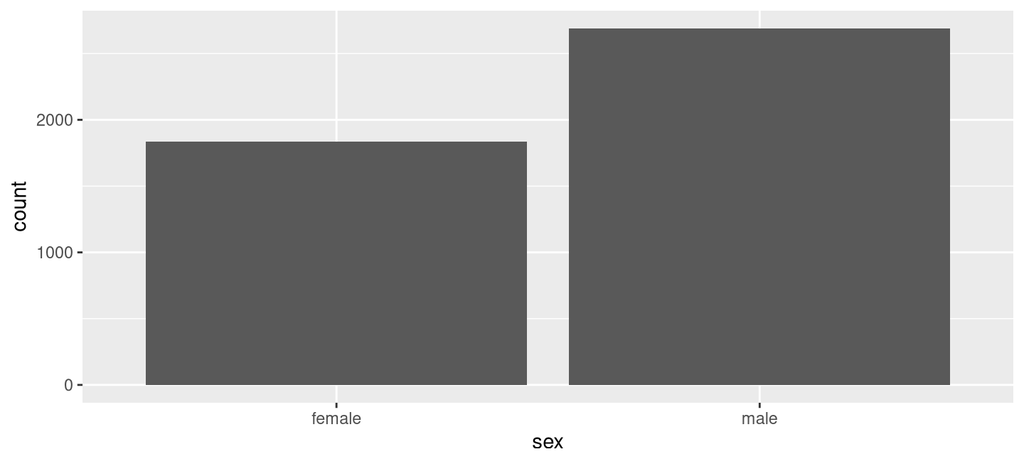

```r
library(ggplot2)             # even better, use library(tidyerse)

ggplot(berkdata, aes(x = sex)) +       # the data we want to plot
  geom_bar()                           # how we want to plot data
```

Add some formatting to get a more useful and pleasing plot. First, a title and more informative x-axis label. We could also change the y-axis label with `y =`.

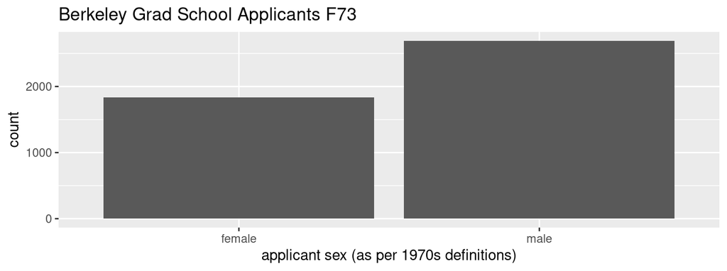

```r
ggplot(berkdata, aes(x = sex)) +
  geom_bar() +
  labs(title = "Berkeley Grad School Applicants F73",
       x = "applicant sex (as per 1970s definitions)")
```

Options `subtitle` and `caption` let us add more information.

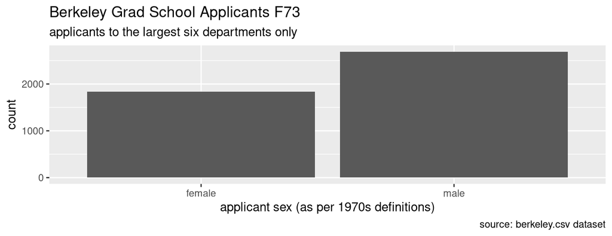

```r
ggplot(berkdata, aes(x = sex)) +
  geom_bar() +
  labs(title = "Berkeley Grad School Applicants F73",
       subtitle = "applicants to the largest six departments only",
       x = "applicant sex (as per 1970s definitions)",
       caption = "source: berkeley.csv dataset")
```

Now some color! Try to choose colorblind-friendly options.

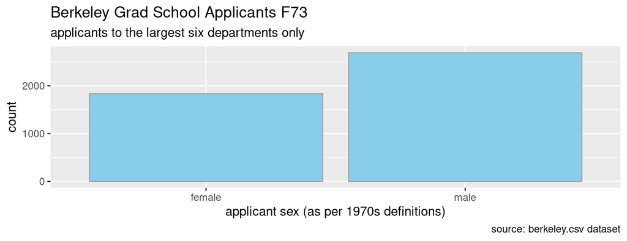

```r
ggplot(berkdata, aes(x = sex)) +
  geom_bar(fill = "skyblue", color = "darkgray") +
  labs(title = "Berkeley Grad School Applicants F73",
       subtitle = "applicants to the largest six departments only",
       x = "applicant sex (as per 1970s definitions)",
       caption = "source: berkeley.csv dataset")
```

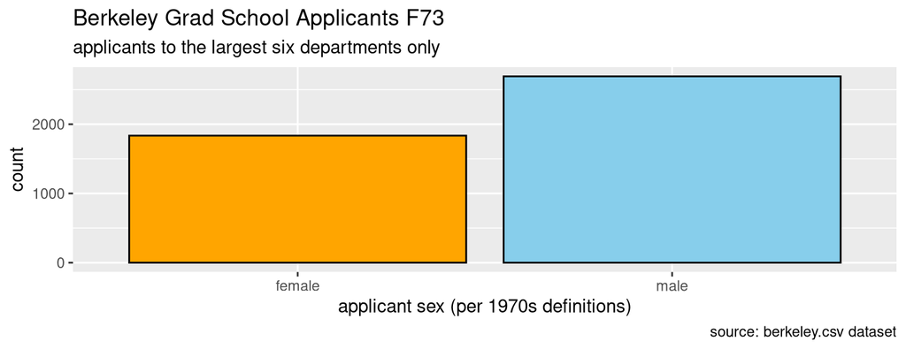

```r
ggplot(berkdata, aes(x = sex, fill = sex)) +     # fill for 2 colors
  geom_bar(color = "black") +                    # add outline color
  scale_fill_manual(values = c("orange", "skyblue")) + # pick colors
  labs(title = "Berkeley Grad School Applicants F73",
       subtitle = "applicants to the largest six departments only",
       x = "applicant sex (per 1970s definitions)",
       caption = "source: berkeley.csv dataset") +
  theme(legend.position = "none")     # remove unneeded fill legend
```

## Proportions Instead of Counts

If we want proportions, we have to calculate them in the plot.

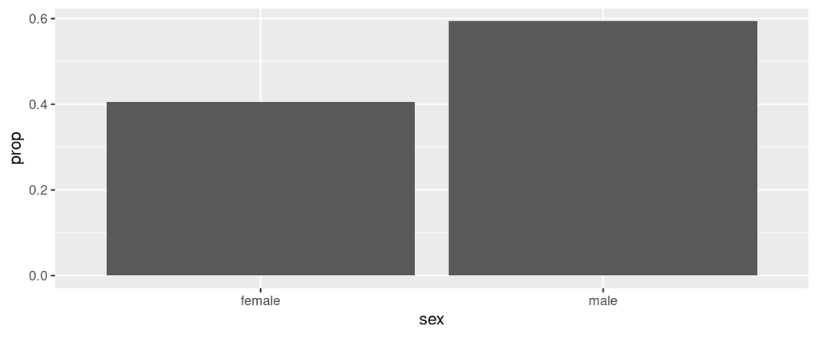

```r
# tells ggplot2 to make the y-axis proportions of the whole group
ggplot(berkdata, aes(x = sex, y = after_stat(prop), group = 1)) +
  geom_bar()
```

## Barplots for Two Variables

One variable is the bars (`x`), while the other variable is how the bars are split (`fill`).

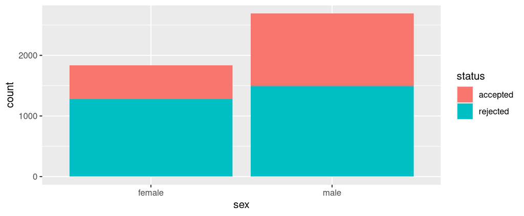

```r
ggplot(berkdata, aes(x = sex, fill = status)) +
  geom_bar()
```

## Bars Side-by-Side (`dodge`) vs. Stacked

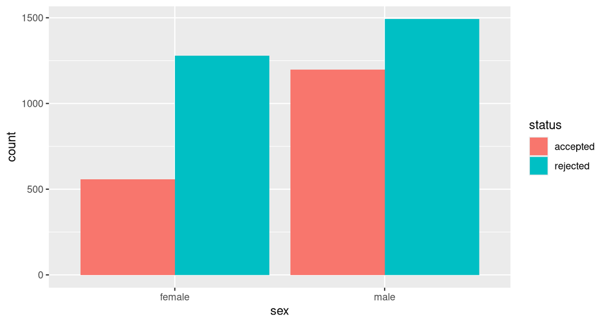

```r
ggplot(berkdata, aes(x = sex, fill = status)) +
  geom_bar(position = "dodge")        # dodge separates the bars
```

## Proportions (`fill`) Instead of Counts

The bars are set to 100% and divided proportionally.

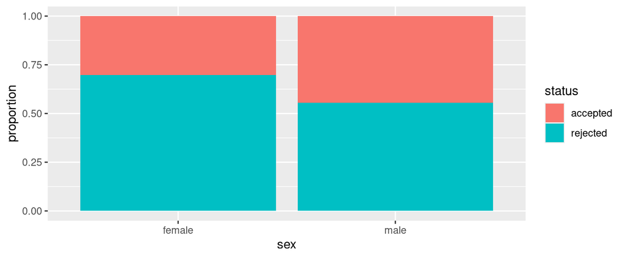

```r
ggplot(berkdata, aes(x = sex, fill = status)) +
  geom_bar(position = "fill") +
  labs(y = "proportion")
```

## Barplots from Summarized Data

We can make a barplot using summarized (tabled) vs. raw data.

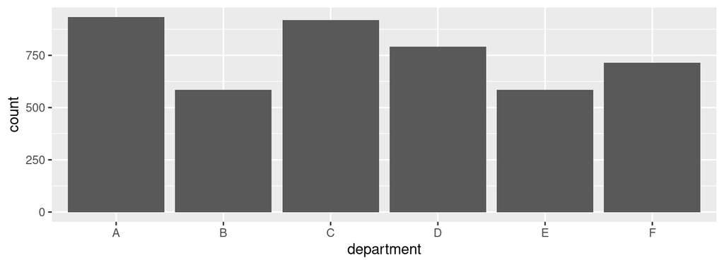

```r
dept_tab <- count(berkdata, department)
ggplot(dept_tab, aes(x = department, y = n)) +
  geom_col() +   # use geom_col() since we are specifying y values
  labs(y = "count")
```

## More About Color

Many sources show color options and built-in palettes for `R`. You can use colors by name (use `colors()` function to show `R`’s list), hex code, or rgb (e.g., [HTML Color Codes](https://htmlcolorcodes.com/color-names/) or [ColorHexa](https://www.colorhexa.com/)). Choose [colorblind safe](https://davidmathlogic.com/colorblind/#%23D81B60-%231E88E5-%23FFC107-%23004D40) color options when sharing plots with others.

- *color* typically refers to points, lines, outlines
- *fill* typically refers to shapes’ internal shading

```r
ggplot(berkdata, aes(x = sex, fill = status)) +
  geom_bar(color = "black") +   # this will be the outline color
  scale_fill_manual(values = c("#FFC20A", "#0C7BDC")) +
  labs(title = "Berkeley Grad Applicants, Fall 1973",
       subtitle = "six departments with largest applicant pools",
       x = "sex of applicant", y = "number of applicants",
       caption = "source: berkeley.csv dataset")
```

## Voila! New Colors

This is a generally colorblind-safe pair of colors, as is the default cyan (#00BFC4) and salmon-ish (#F8766D) combination seen in the earlier two-variable plots.

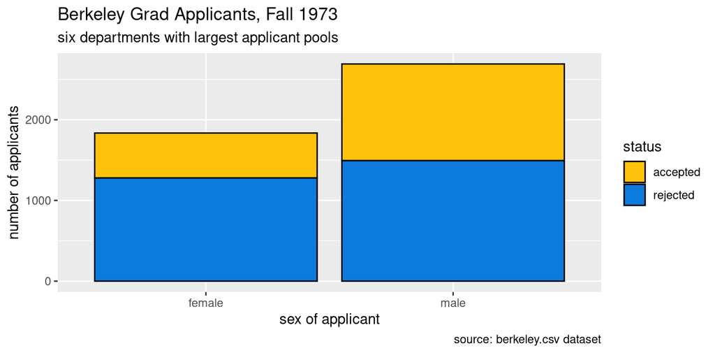

## Three Variables? Use Faceting

Faceting creates multiple “panes” in a plot using some chosen grouping variable(s). Each pane displays the same kind of plot for a given subgroup. Use `facet_wrap()` ([documentation](https://ggplot2.tidyverse.org/reference/facet_wrap.html)) or `facet_grid()` ([documentation](https://ggplot2.tidyverse.org/reference/facet_grid.html)), depending on your need.

```r
ggplot(berkdata, aes(x = sex, fill = status)) +
  geom_bar() +
  scale_fill_manual(values = c("#FFC20A", "#0C7BDC")) +
  labs(title = "Berkeley Grad Applicants, Fall 1973",
       subtitle = "six departments with largest applicant pools",
       caption = "source: berkeley.csv dataset",
       x = "sex of applicant",
       y = "number of applicants") +
  facet_grid(rows = vars(department))
```

Six plots configured into a faceted grid show `status` for men vs. women, with one plot (row) for each department.

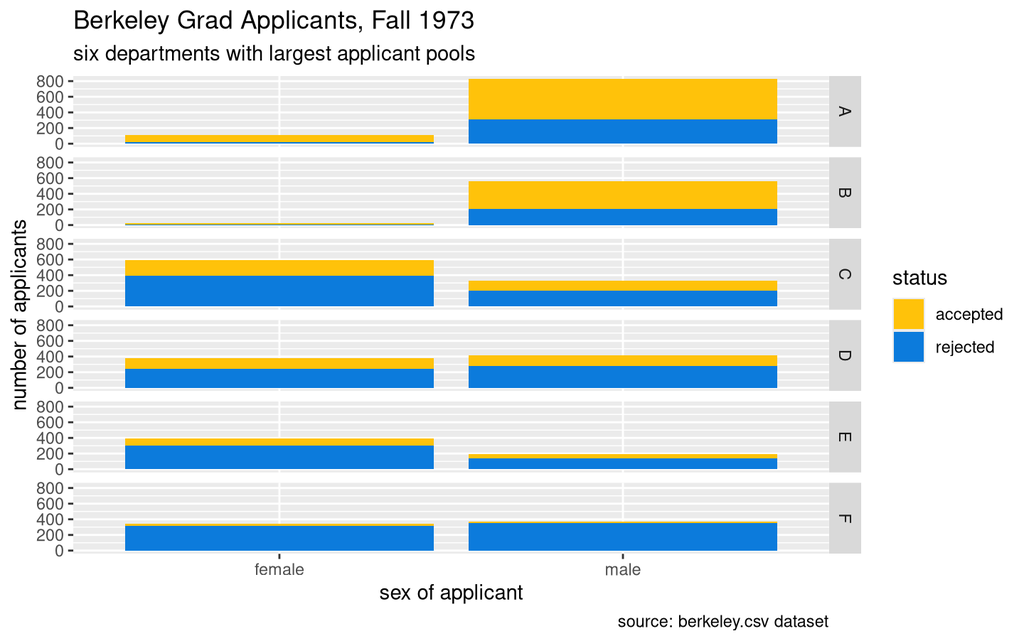

We can switch the orientation of the facets, so departments are columns. What are the pros and cons of this plot versus the one where departments are rows? Can you discern any patterns?

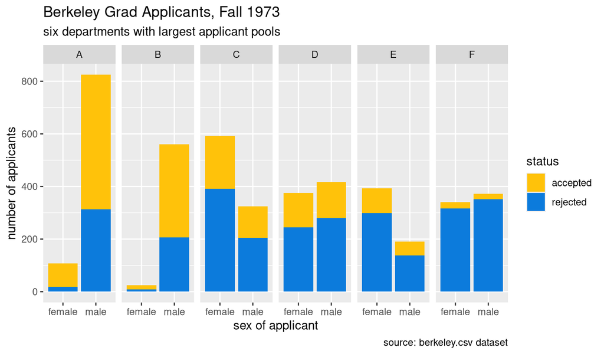

## A Quick Word about Faceting

Statisticians and others have struggled with how to effectively and efficiently visualize *multivariate data*. We often use colors or shapes, but the result can be messy.

The `facet_grid()` function creates separate plots for a given variable or variables and arranges them in a grid or matrix, as specified by row and column variables. The grid dimensions are determined by how many levels (categories or unique values) each variable has.

The `facet_wrap()` function tries to optimize for a rectangular arrangement of the resulting plots.

Conceptually, faceting in a plot is similar to using `group_by()` when computing summaries.

## Using `facet.wrap()` vs. `facet.grid()`

Plots using `facet_wrap(vars(department))`. With 6 plots, the 2 \(\times\) 3 grid is an “optimal” wrapped layout for this space.

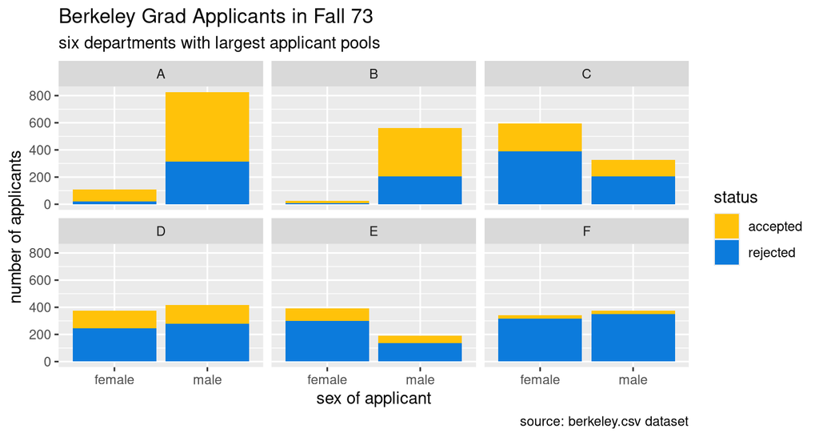

## Mosaic Plot

We can make a [mosaic plot](https://cran.r-project.org/web/packages/vcdExtra/vignettes/a4-mosaics.html) using the `mosaic()` function from the `vcd` (visualizing categorical data) package. A mosaic plot is an area-proportional visualization of a frequency table where tile sizes represent counts. Bigger tiles are more cases.

First we have to tabulate the data using `structable()`. As the name suggests, it produces a structured table for two or more categorical variables.

```r
library(vcd)
berktab <- structable(status ~ department + sex, data = berkdata)
```

Notice the output of this function on the next slide. The `status` variable is the columns of the table, and the other two variables form the table’s rows.

```r
berktab
```

```
                  status accepted rejected
department sex
A          female              89       19
           male               512      313
B          female              17        8
           male               353      207
C          female             202      391
           male               120      205
D          female             131      244
           male               138      279
E          female              94      299
           male                53      138
F          female              24      317
           male                22      351
```

The table structure determines the layout. What does it show?

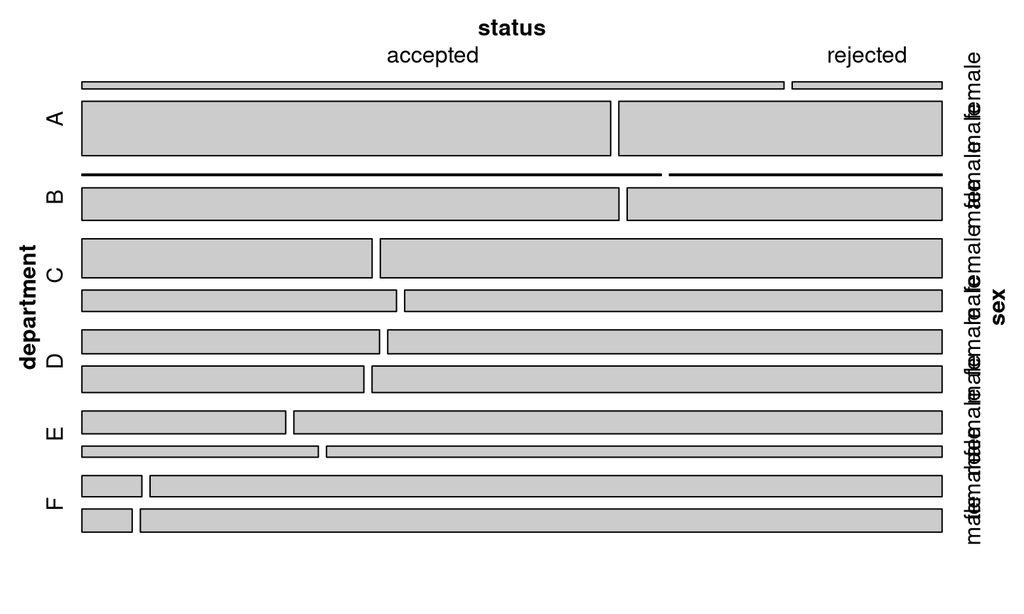

```r
mosaic(berktab)
```

We can rotate the category labels for (possibly) easier reading.

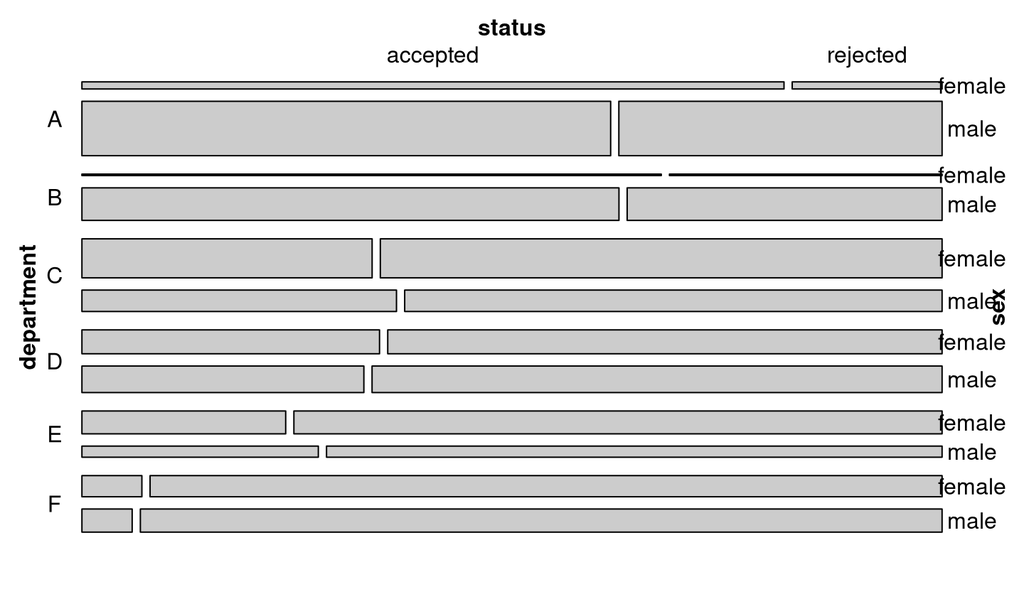

```r
mosaic(berktab, labeling = labeling_border(rot_labels = c(0, 0, 90)))
```

We can force a different structure for another visualization.

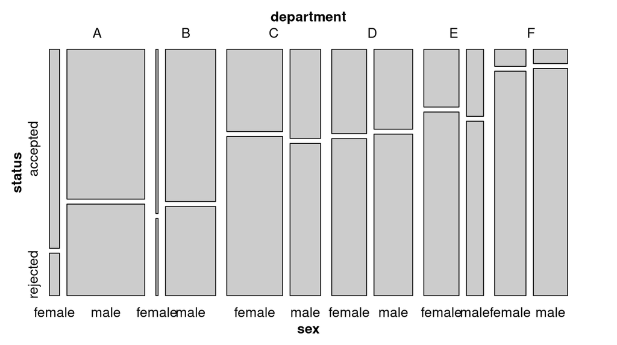

```r
# department and sex are now the columns, aka vertical or "v"
mosaic(berktab, direction = c("v","v","h"))
```

## Waffle Plots

We can make waffle plots using `geom_waffle()` option from the `waffle` package. Create a proportion (percentage) table of data to be plotted. We will merge the two categorical variable names so there is a vector of categories and a vector of corresponding rounded percentages.

```r
waffledat <- berkdata %>%
  count(sex, status) %>%
  mutate(pct = round(100 * prop.table(n))) %>%    # find percents
  select(-n) %>%                          # drop the count column
  unite(col = sex_status, sex, status, sep = " ")
```

The `unite()` function inputs are the name of the new column you are making, the columns you are combining, and how you want the column contents separated (space, underscore, etc).

Our rounded percentages add to 99, so the waffle plot will have 99 versus 100 squares. There will be four colors in the plot, one for each combined sex-status category.

```r
waffledat
```

```
# A tibble: 4 × 2
  sex_status        pct
  <chr>           <dbl>
1 female accepted    12
2 female rejected    28
3 male accepted      26
4 male rejected      33
```

As you will see on the next slide, the columns will serve as the aesthetic inputs: `aes(fill = sex_status, values = pct)`.

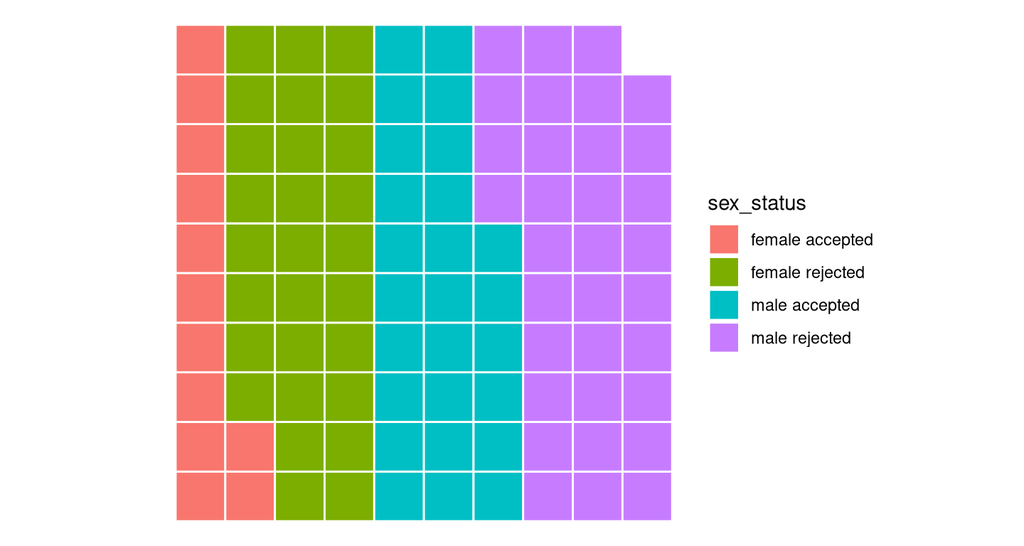

```r
library(waffle)
ggplot(waffledat, aes(fill = sex_status, values = pct)) +
  geom_waffle(color = "white", size = 0.5) + #format grid spaces
  coord_equal() +                  # spaces axes to make squares
  theme_void()                        # eliminates axis markings
```

## Drawing Conclusions

- Women were more likely to apply to departments that were harder to get into. There were far fewer female applicants to A and B, which accept more than 60% of all applicants. What looks like an overall bias is a result of this phenomenon. The individual departments sometimes *favor* women (which you will see when we revisit this dataset).
- Do you prefer tables or plots for exploring these data? Why?
- Are there other summaries that would help you understand these data better? What other data would you like to have?

Bickel, P. J., Hammel, E. A., & O’Connell, J. W. (1975). Sex bias in graduate admissions: Data from Berkeley. *Science*, 187(4175), 398–404. http://doi.org/10.1126/science.187.4175.398 ↩